# Pratical Machine Learning Course_Project

Six_Paths

02 Juillet 2019

## Pratical Machine Learning

#### Summary :

This project is based on personal activicty data collected relatively inexpensively using quantified self movement’s devices such as Jawbone Up, Nike FuelBand, and Fitbit. Performing barbell lifts correctly and incorrectly in 5 different ways, we want to focus on how well this activity is done and not to quantify it.

Using data from accelerometers on the belt, forearm, arm, and dumbell of 6 participants, the objective is to predict the manner in which they did the exercise. With relevant variable, this report describe how the model is built through the different modeling choices. Final model is also used to predict 20 different test cases.

```r
  ## Set working directory
  remove(list=ls())
  setwd("C:/Users/686004/Desktop/Six_Paths/D_S/08 - Pratical Machine Learning")
  set.seed(325)
  library(data.table)
  library(caret)
```

```r
  library(caret)
  suppressMessages(library(rattle))
  library(rpart.plot)
```

## Load and clearing data

### Load data

```r
  train_data <- read.csv("https://d396qusza40orc.cloudfront.net/predmachlearn/pml-training.csv")
  test_data <- read.csv("https://d396qusza40orc.cloudfront.net/predmachlearn/pml-testing.csv")
  str(train_data)
```

```
## 'data.frame':    19622 obs. of  160 variables:
##  $ X                       : int  1 2 3 4 5 6 7 8 9 10 ...
##  $ user_name               : Factor w/ 6 levels "adelmo","carlitos",..: 2 2 2 2 2 2 2 2 2 2 ...
##  $ raw_timestamp_part_1    : int  1323084231 1323084231 1323084231 1323084232 1323084232 1323084232 1323084232 1323084232 1323084232 1323084232 ...
##  $ raw_timestamp_part_2    : int  788290 808298 820366 120339 196328 304277 368296 440390 484323 484434 ...
##  $ cvtd_timestamp          : Factor w/ 20 levels "02/12/2011 13:32",..: 9 9 9 9 9 9 9 9 9 9 ...
##  $ new_window              : Factor w/ 2 levels "no","yes": 1 1 1 1 1 1 1 1 1 1 ...
##  $ num_window              : int  11 11 11 12 12 12 12 12 12 12 ...
##  $ roll_belt               : num  1.41 1.41 1.42 1.48 1.48 1.45 1.42 1.42 1.43 1.45 ...
##  $ pitch_belt              : num  8.07 8.07 8.07 8.05 8.07 8.06 8.09 8.13 8.16 8.17 ...
##  $ yaw_belt                : num  -94.4 -94.4 -94.4 -94.4 -94.4 -94.4 -94.4 -94.4 -94.4 -94.4 ...
##  $ total_accel_belt        : int  3 3 3 3 3 3 3 3 3 3 ...
##  $ kurtosis_roll_belt      : Factor w/ 397 levels "","-0.016850",..: 1 1 1 1 1 1 1 1 1 1 ...
##  $ kurtosis_picth_belt     : Factor w/ 317 levels "","-0.021887",..: 1 1 1 1 1 1 1 1 1 1 ...
##  $ kurtosis_yaw_belt       : Factor w/ 2 levels "","#DIV/0!": 1 1 1 1 1 1 1 1 1 1 ...
```

[output cut: 86 more lines]

The train database contains 19622 observations of 160 variables. As can be seen, several variables have missing’‘NA’’ and/or empty values. These data will then be processed in order to have a complete database for modelling. All variables with more than of NA and/or missing data will be deleted

### Data clearing

```r
  # Data Clearing
    # Delete inconsistent data
    delete_index <- which((colSums(is.na(train_data) | train_data==''))/(nrow(train_data)) > 0.5)
    train_data <- train_data [, -delete_index]
    test_data <- test_data [, -delete_index]
    print(dim(train_data))
```

```
## [1] 19622    60
```

```r
    print ("Final data have 60 variable (after 100 columns deleted)")
```

```
## [1] "Final data have 60 variable (after 100 columns deleted)"
```

```r
    # Split original train_data in train and test
    inTrain = createDataPartition(train_data$classe, p = 0.8, list=FALSE)
    training = train_data[ inTrain, -1]
    testing = train_data[-inTrain, -1]
```

## Modelling

### Decision tree

```r
   # Set model control params
    fit_control <- trainControl(method = "cv", number = 5)
```

```r
  ## Decision tree
    dt_model <- caret::train(classe~ ., data = training, method="rpart",
                             trControl = fit_control)
    print(dt_model)
```

```
## CART
##
## 15699 samples
##    58 predictor
##     5 classes: 'A', 'B', 'C', 'D', 'E'
##
## No pre-processing
## Resampling: Cross-Validated (5 fold)
## Summary of sample sizes: 12560, 12560, 12557, 12560, 12559
## Resampling results across tuning parameters:
##
##   cp          Accuracy   Kappa
##   0.04049844  0.5407410  0.42286347
##   0.04566088  0.4393194  0.24771759
##   0.11615487  0.3315566  0.07205176
##
## Accuracy was used to select the optimal model using the largest value.
## The final value used for the model was cp = 0.04049844.
```

Accuracy of the different fold on this decision tree model is very low, the maximum being below 55%.

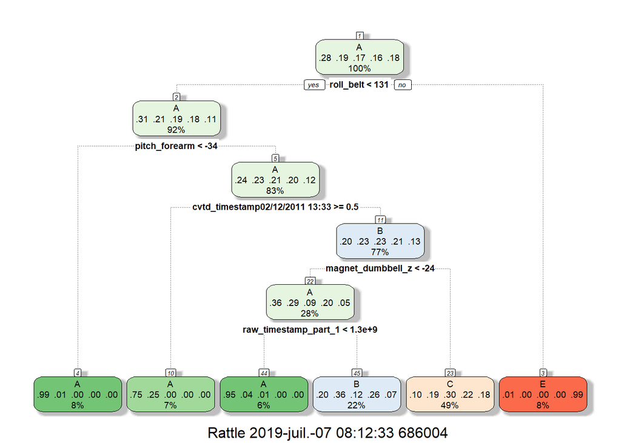

```r
  fancyRpartPlot(dt_model$finalModel)
```

```r
  dt_pred <- predict(dt_model, testing[ , !(names(testing) %in% 'classe')])
  confusionMatrix(dt_pred, testing$classe)#$overall['Accuracy']
```

```
## Confusion Matrix and Statistics
##
##           Reference
## Prediction   A   B   C   D   E
##          A 730  85   0   0   0
##          B 186 289 104 228  60
##          C 195 385 580 415 344
##          D   0   0   0   0   0
##          E   5   0   0   0 317
##
## Overall Statistics
##
##                Accuracy : 0.4884
##                  95% CI : (0.4726, 0.5042)
##     No Information Rate : 0.2845
##     P-Value [Acc > NIR] : < 2.2e-16
##
##                   Kappa : 0.3587
##
##  Mcnemar's Test P-Value : NA
##
## Statistics by Class:
##
##                      Class: A Class: B Class: C Class: D Class: E
## Sensitivity            0.6541  0.38076   0.8480   0.0000  0.43967
## Specificity            0.9697  0.81732   0.5866   1.0000  0.99844
## Pos Pred Value         0.8957  0.33333   0.3022      NaN  0.98447
## Neg Pred Value         0.8758  0.84620   0.9481   0.8361  0.88781
## Prevalence             0.2845  0.19347   0.1744   0.1639  0.18379
## Detection Rate         0.1861  0.07367   0.1478   0.0000  0.08081
## Detection Prevalence   0.2077  0.22100   0.4892   0.0000  0.08208
## Balanced Accuracy      0.8119  0.59904   0.7173   0.5000  0.71905
```

With an accuracy of 48.84% on a validation set, the decision tree does not seem to be suitable for this dataset. This model have a too large out of sample error (51.16%). The out of sample is a measure of how accurately an algorithm is able to predict outcome values for previously unseen data

### Radom forest

```r
    rf_model <- caret::train(classe~ ., data = training, method="rf",
                            trControl = fit_control)
    print(rf_model)
```

```
## Random Forest
##
## 15699 samples
##    58 predictor
##     5 classes: 'A', 'B', 'C', 'D', 'E'
##
## No pre-processing
## Resampling: Cross-Validated (5 fold)
## Summary of sample sizes: 12558, 12559, 12560, 12559, 12560
## Resampling results across tuning parameters:
##
##   mtry  Accuracy   Kappa
##    2    0.9898722  0.9871871
##   41    0.9994268  0.9992750
##   80    0.9987261  0.9983888
##
## Accuracy was used to select the optimal model using the largest value.
## The final value used for the model was mtry = 41.
```

```r
    rf_pred <- predict(rf_model, testing[ , !(names(testing) %in% 'classe')])
    confusionMatrix(rf_pred, testing$classe)#$overall['Accuracy']
```

```
## Confusion Matrix and Statistics
##
##           Reference
## Prediction    A    B    C    D    E
##          A 1116    0    0    0    0
##          B    0  759    1    0    0
##          C    0    0  683    0    0
##          D    0    0    0  643    0
##          E    0    0    0    0  721
##
## Overall Statistics
##
##                Accuracy : 0.9997
##                  95% CI : (0.9986, 1)
##     No Information Rate : 0.2845
##     P-Value [Acc > NIR] : < 2.2e-16
##
##                   Kappa : 0.9997
##
##  Mcnemar's Test P-Value : NA
##
## Statistics by Class:
##
##                      Class: A Class: B Class: C Class: D Class: E
## Sensitivity            1.0000   1.0000   0.9985   1.0000   1.0000
## Specificity            1.0000   0.9997   1.0000   1.0000   1.0000
## Pos Pred Value         1.0000   0.9987   1.0000   1.0000   1.0000
## Neg Pred Value         1.0000   1.0000   0.9997   1.0000   1.0000
## Prevalence             0.2845   0.1935   0.1744   0.1639   0.1838
## Detection Rate         0.2845   0.1935   0.1741   0.1639   0.1838
## Detection Prevalence   0.2845   0.1937   0.1741   0.1639   0.1838
## Balanced Accuracy      1.0000   0.9998   0.9993   1.0000   1.0000
```

With 99.97% accuracy on validation set and 0.03% for out of sample error, random forest has better perofrmance than decision tree.

### Gradient boosting

```r
   gb_model <- caret::train(classe~ ., data = training, method="gbm",
                             verbose = FALSE)
    print(gb_model)
```

```
## Stochastic Gradient Boosting
##
## 15699 samples
##    58 predictor
##     5 classes: 'A', 'B', 'C', 'D', 'E'
##
## No pre-processing
## Resampling: Bootstrapped (25 reps)
## Summary of sample sizes: 15699, 15699, 15699, 15699, 15699, 15699, ...
## Resampling results across tuning parameters:
##
##   interaction.depth  n.trees  Accuracy   Kappa
##   1                   50      0.8349001  0.7903802
##   1                  100      0.8965759  0.8689527
##   1                  150      0.9241976  0.9039100
##   2                   50      0.9557120  0.9438915
##   2                  100      0.9848317  0.9807996
##   2                  150      0.9907229  0.9882578
##   3                   50      0.9814586  0.9765259
##   3                  100      0.9925153  0.9905265
##   3                  150      0.9956965  0.9945527
##
## Tuning parameter 'shrinkage' was held constant at a value of 0.1
##
## Tuning parameter 'n.minobsinnode' was held constant at a value of 10
## Accuracy was used to select the optimal model using the largest value.
## The final values used for the model were n.trees = 150,
##  interaction.depth = 3, shrinkage = 0.1 and n.minobsinnode = 10.
```

We have another accurate model around 99.60% with optimal parameters (n.trees = 150, interaction.depth = 3, shrinkage = 0.1 and n.minobsinnode = 10).

```r
    gb_pred <- predict(gb_model, testing[ , !(names(testing) %in% 'classe')])
    confusionMatrix(gb_pred, testing$classe)#$overall['Accuracy']
```

```
## Confusion Matrix and Statistics
##
##           Reference
## Prediction    A    B    C    D    E
##          A 1116    0    0    0    0
##          B    0  757    1    0    0
##          C    0    1  681    1    0
##          D    0    1    2  642    2
##          E    0    0    0    0  719
##
## Overall Statistics
##
##                Accuracy : 0.998
##                  95% CI : (0.996, 0.9991)
##     No Information Rate : 0.2845
##     P-Value [Acc > NIR] : < 2.2e-16
##
##                   Kappa : 0.9974
##
##  Mcnemar's Test P-Value : NA
##
## Statistics by Class:
##
##                      Class: A Class: B Class: C Class: D Class: E
## Sensitivity            1.0000   0.9974   0.9956   0.9984   0.9972
## Specificity            1.0000   0.9997   0.9994   0.9985   1.0000
## Pos Pred Value         1.0000   0.9987   0.9971   0.9923   1.0000
## Neg Pred Value         1.0000   0.9994   0.9991   0.9997   0.9994
## Prevalence             0.2845   0.1935   0.1744   0.1639   0.1838
## Detection Rate         0.2845   0.1930   0.1736   0.1637   0.1833
## Detection Prevalence   0.2845   0.1932   0.1741   0.1649   0.1833
## Balanced Accuracy      1.0000   0.9985   0.9975   0.9985   0.9986
```

Accuray on validation set is around 99.80% with gradient boosting. This is slightly lower than the performance of random forest and out of sample error is also greater (0.20%).

### Prediction with final chosen model

The random forest offering a better performance will be chosen as the final model and will be used to predict cases.

```r
    final_model <- rf_model
    rf_pred_case <- predict(final_model, test_data[ , !(names(test_data) %in% 'classe')][, -1])
    rf_pred_case
```

```
##  [1] B A B A A E D B A A B C B A E E A B B B
## Levels: A B C D E
```

```r
    ## Save prediction
    df_case_predict <- do.call(rbind, Map(data.frame, Case=test_data$X, predict=rf_pred_case))
    write.csv(df_case_predict, "Predictions_save.csv", row.names=FALSE)
```